# A Predictive Model for Weight Lifting Biomechanics

### Practical Machine Learning

### Johns Hopkins Data Science Specialization

This analysis aims to classify correct and incorrect biomechanics during a weightlifting exercise. The source data was collected and made available by Eduardo Velloso et. al. The team of researchers attached an array of accelerometers to specified body locations of a set of study participants. The participants were instructed to perform a dumbbell curl correctly (Class A), and incorrectly in 4 specific ways (Class B - throwing elbows to the front, Class C - lifting the dumbbel only halfway, Class D - . lowering the dumbbel only halfway, and Class E - throwing the hips foreward). The research team collected data from the motion sensors during each class of the exercise. They were able to build a classification model that was able to accurately determine whether the curl was done correctly, or incorrectly in a specific way. They also kindly made their data public for others to work with. More information about the study can be found [here](http://groupware.les.inf.puc-rio.br/har).

Let’s start the analysis by loading the data, which is already split into training and test sets.

```r
library(caret)
training <- read.csv("pml-training.csv")
testing <- read.csv("pml-testing.csv")
str(training)
```

```
## 'data.frame':    19622 obs. of  160 variables:
##  $ X                       : int  1 2 3 4 5 6 7 8 9 10 ...
##  $ user_name               : Factor w/ 6 levels "adelmo","carlitos",..: 2 2 2 2 2 2 2 2 2 2 ...
##  $ raw_timestamp_part_1    : int  1323084231 1323084231 1323084231 1323084232 1323084232 1323084232 1323084232 1323084232 1323084232 1323084232 ...
##  $ raw_timestamp_part_2    : int  788290 808298 820366 120339 196328 304277 368296 440390 484323 484434 ...
##  $ cvtd_timestamp          : Factor w/ 20 levels "02/12/2011 13:32",..: 9 9 9 9 9 9 9 9 9 9 ...
##  $ new_window              : Factor w/ 2 levels "no","yes": 1 1 1 1 1 1 1 1 1 1 ...
##  $ num_window              : int  11 11 11 12 12 12 12 12 12 12 ...
##  $ roll_belt               : num  1.41 1.41 1.42 1.48 1.48 1.45 1.42 1.42 1.43 1.45 ...
##  $ pitch_belt              : num  8.07 8.07 8.07 8.05 8.07 8.06 8.09 8.13 8.16 8.17 ...
##  $ yaw_belt                : num  -94.4 -94.4 -94.4 -94.4 -94.4 -94.4 -94.4 -94.4 -94.4 -94.4 ...
##  $ total_accel_belt        : int  3 3 3 3 3 3 3 3 3 3 ...
##  $ kurtosis_roll_belt      : Factor w/ 397 levels "","-0.016850",..: 1 1 1 1 1 1 1 1 1 1 ...
##  $ kurtosis_picth_belt     : Factor w/ 317 levels "","-0.021887",..: 1 1 1 1 1 1 1 1 1 1 ...
##  $ kurtosis_yaw_belt       : Factor w/ 2 levels "","#DIV/0!": 1 1 1 1 1 1 1 1 1 1 ...
```

[output cut: 86 more lines]

The training data set consists of nearly 20,000 observations of 160 variables. From summary we can see that the column classes need a little work. Many of columns containing numeric data are not classified as such. Getting the column classes in order is the first step in preparing for analysis.

```r
#set correct column classes
for(i in 10:159) training[,i] <- as.numeric(as.character(training[,i]))
```

With that corrected, let’s start narrowing down the 160 potential predictors to the ones that are most pertinent to the classification problem. A good first step is removing columns that have have very little variance, and thus are not good predictors. This is done with the nearZeroVar function. It is also apparent from the str summary above that several of the columns contain NA values. Let’s also drop columns that contain more than 30% NAs, as those are also less than ideal predictors.

```r
#drop columns with near zero variance
zero_var_index <- nearZeroVar(training)
train_var <- training[,-zero_var_index]
dim(train_var)
```

```
## [1] 19622   124
```

```r
names(train_var)
```

```
##   [1] "X"                        "user_name"
##   [3] "raw_timestamp_part_1"     "raw_timestamp_part_2"
##   [5] "cvtd_timestamp"           "num_window"
##   [7] "roll_belt"                "pitch_belt"
##   [9] "yaw_belt"                 "total_accel_belt"
##  [11] "kurtosis_roll_belt"       "kurtosis_picth_belt"
##  [13] "skewness_roll_belt"       "skewness_roll_belt.1"
##  [15] "max_roll_belt"            "max_picth_belt"
##  [17] "max_yaw_belt"             "min_roll_belt"
##  [19] "min_pitch_belt"           "min_yaw_belt"
##  [21] "amplitude_roll_belt"      "amplitude_pitch_belt"
##  [23] "var_total_accel_belt"     "avg_roll_belt"
##  [25] "stddev_roll_belt"         "var_roll_belt"
##  [27] "avg_pitch_belt"           "stddev_pitch_belt"
##  [29] "var_pitch_belt"           "avg_yaw_belt"
```

[output cut: 47 more lines]

```r
#drop columns with >30% NA values
percent_NA <- function(x) sum(is.na(x))/length(x)
train_NA <- sapply(train_var[,1:124], percent_NA)
train_NA_index <- train_NA<0.3
train_lessNA <- train_var[,train_NA_index]
dim(train_lessNA)
```

```
## [1] 19622    59
```

Those two conditions have dropped the list of potential predictors to 58, which is a little more manageable. It would be good if the model did not consider the effect of the individual participants, since it could be more easily generalized. The data from the motion sensors, in columns 7-58, seem the most pertinent. Let’s create a feature plot of those predictors vs the activity class to see if any clear patterns are present.

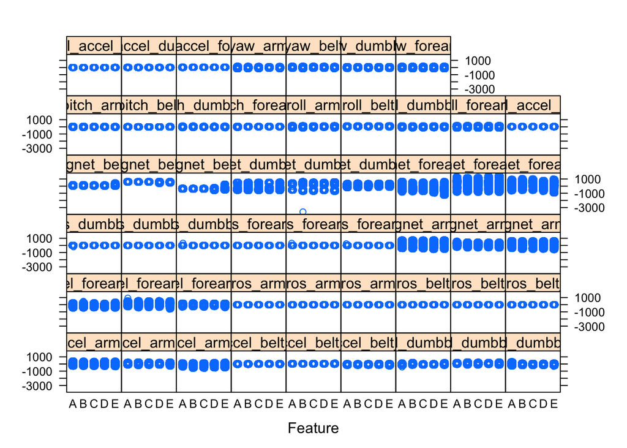

```r
#plot predictors against response
featurePlot(x = train_lessNA[,7:58], y = train_lessNA[,59], plot = "strip", jitter = TRUE)
```

```r
min(train_lessNA[,7:58])
```

```
## [1] -3600
```

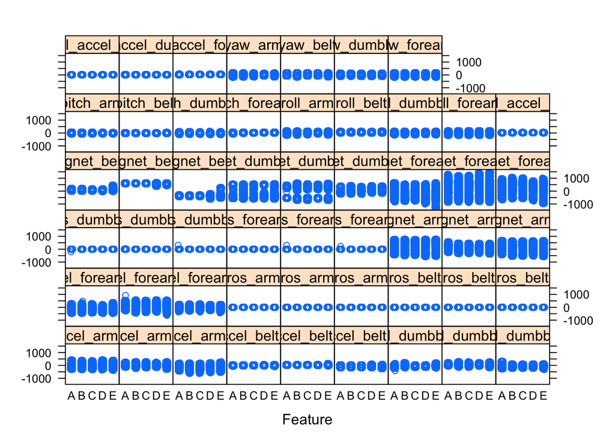

```r
index <- train_lessNA == -3600
train_lessNA[index] <- NA

#set remaining NA values to respective column medians
colmedians <- sapply(train_lessNA[,7:58], median)
for(i in 7:58){
    index2 <- is.na(train_lessNA[,i])
    train_lessNA[index2, i] <- colmedians[i]
}

#feature plot with outlier removed
featurePlot(x = train_lessNA[,7:58], y = train_lessNA[,59], plot = "strip", jitter = TRUE)
```

The second set of feature plots is a little more clear with the outlier removed. Some variables seem to take slightly different distributions based on the activity classification, but again it is not too obvious. Let’s take a random subset of the training data and begin creating some models to hone in on the important relationships.

```r
#declare final processed training set
train_final <- train_lessNA
rm(train_lessNA)

train_sub <- train_final[sample(1:nrow(train_final), size = 5000, replace = FALSE),]
```

Priciple component analysis is a good strategy to narrow down the dimensionality of the data, and possibly explain most of the variance by combining the predictors into a few principle compnents. Let’s create a set of PCAs for the subset of the training data, using 80% variance retained as a threshold, and then use those PCAs as predictors in a basic partition model.

```r
#PCA
preproc <- preProcess(train_sub[,7:58], method = "pca", thresh = 0.8)
trainPCA <- predict(preproc, train_sub[,7:58])

#try partition model with PCAs as features
fit <- train(train_sub$classe ~ ., method = "rpart", data = trainPCA)
confusionMatrix(train_sub$classe, predict(fit))
```

```
## Confusion Matrix and Statistics
##
##           Reference
## Prediction    A    B    C    D    E
##          A 1136  246    0   75    0
##          B  435  314    0  157   11
##          C  579  239    0   66    0
##          D  336  175    0  267   49
##          E  386  311    0  111  107
##
## Overall Statistics
##
##                Accuracy : 0.3648
##                  95% CI : (0.3514, 0.3783)
##     No Information Rate : 0.5744
##     P-Value [Acc > NIR] : 1
##
##                   Kappa : 0.1609
##  Mcnemar's Test P-Value : NA
##
## Statistics by Class:
##
##                      Class: A Class: B Class: C Class: D Class: E
## Sensitivity            0.3955   0.2444       NA   0.3950   0.6407
## Specificity            0.8492   0.8377   0.8232   0.8705   0.8328
## Pos Pred Value         0.7797   0.3424       NA   0.3229   0.1169
## Neg Pred Value         0.5100   0.7622       NA   0.9020   0.9853
## Prevalence             0.5744   0.2570   0.0000   0.1352   0.0334
## Detection Rate         0.2272   0.0628   0.0000   0.0534   0.0214
## Detection Prevalence   0.2914   0.1834   0.1768   0.1654   0.1830
## Balanced Accuracy      0.6223   0.5410       NA   0.6327   0.7368
```

```r
#well that didn't work out so well let's just try all the predictors
fit2 <- train(train_sub$classe ~ ., method = "rpart", data = train_sub[,7:58])
confusionMatrix(train_final$classe, predict(fit2, newdata = train_final))
```

```
## Confusion Matrix and Statistics
##
##           Reference
## Prediction    A    B    C    D    E
##          A 4267  162 1010   67   74
##          B  936 1770  772  319    0
##          C  243  200 2681  298    0
##          D  342  234 1692  948    0
##          E  174  762  847  125 1699
##
## Overall Statistics
##
##                Accuracy : 0.5792
##                  95% CI : (0.5723, 0.5861)
##     No Information Rate : 0.3568
##     P-Value [Acc > NIR] : < 2.2e-16
##
##                   Kappa : 0.4668
##  Mcnemar's Test P-Value : < 2.2e-16
##
## Statistics by Class:
##
##                      Class: A Class: B Class: C Class: D Class: E
## Sensitivity            0.7157   0.5659   0.3829  0.53956  0.95826
## Specificity            0.9039   0.8771   0.9413  0.87305  0.89310
## Pos Pred Value         0.7647   0.4662   0.7835  0.29478  0.47103
## Neg Pred Value         0.8793   0.9142   0.7333  0.95069  0.99538
## Prevalence             0.3038   0.1594   0.3568  0.08954  0.09036
## Detection Rate         0.2175   0.0902   0.1366  0.04831  0.08659
## Detection Prevalence   0.2844   0.1935   0.1744  0.16390  0.18382
## Balanced Accuracy      0.8098   0.7215   0.6621  0.70630  0.92568
```

Let’s try a more sophisticated approach, a random forest model, to see if we can improve the classification accuracy.

```r
fit4 <- train(train_sub$classe ~ .,method = "rf", data = train_sub[,7:58])
confusionMatrix(train_final$classe, predict(fit4, newdata = train_final))
```

```
## Confusion Matrix and Statistics
##
##           Reference
## Prediction    A    B    C    D    E
##          A 5569    6    4    1    0
##          B   58 3673   55    8    3
##          C    0   37 3369   16    0
##          D    0    3   59 3146    8
##          E    1    8   12   18 3568
##
## Overall Statistics
##
##                Accuracy : 0.9849
##                  95% CI : (0.9831, 0.9865)
##     No Information Rate : 0.2868
##     P-Value [Acc > NIR] : < 2.2e-16
##
##                   Kappa : 0.9809
##  Mcnemar's Test P-Value : 2.358e-16
##
## Statistics by Class:
##
##                      Class: A Class: B Class: C Class: D Class: E
## Sensitivity            0.9895   0.9855   0.9628   0.9865   0.9969
## Specificity            0.9992   0.9922   0.9967   0.9957   0.9976
## Pos Pred Value         0.9980   0.9673   0.9845   0.9782   0.9892
## Neg Pred Value         0.9958   0.9966   0.9920   0.9974   0.9993
## Prevalence             0.2868   0.1899   0.1783   0.1625   0.1824
## Detection Rate         0.2838   0.1872   0.1717   0.1603   0.1818
## Detection Prevalence   0.2844   0.1935   0.1744   0.1639   0.1838
## Balanced Accuracy      0.9944   0.9889   0.9798   0.9911   0.9972
```

Thankfully all that computation time has made a big difference. The random forest model trained on the 5000 row subset was able to predict class in the larger training set with 98% accuracy. The sensitivity and specificity within each class are also quite high. This certainly looks like a promising approach. Let’s now train the random forest model with the entire training data set.

```r
fit5 <- train(train_final$classe ~ .,method = "rf", data = train_final[,7:58])
fit5
```

```
## Random Forest
##
## 19622 samples
##    51 predictor
##     5 classes: 'A', 'B', 'C', 'D', 'E'
##
## No pre-processing
## Resampling: Bootstrapped (25 reps)
##
## Summary of sample sizes: 19622, 19622, 19622, 19622, 19622, 19622, ...
##
## Resampling results across tuning parameters:
##
##   mtry  Accuracy   Kappa      Accuracy SD  Kappa SD
##    2    0.9924948  0.9905043  0.001252550  0.001584482
##   27    0.9923049  0.9902648  0.001451358  0.001835425
##   52    0.9843000  0.9801362  0.003838791  0.004858839
##
## Accuracy was used to select the optimal model using  the largest value.
## The final value used for the model was mtry = 2.
```

Training the random forest model on the whole final training set resulted in a fit that acheived quite high accuracy on the bootstrap resamples. The optimal model used only two variable choices at each node, but the accuracy was pretty stable across a range of mtry settings. Below is a list of the important features, sorted from highest to lowest.

```r
varImp(fit5)
```

```
## rf variable importance
##
##   only 20 most important variables shown (out of 52)
##
##                   Overall
## roll_belt          100.00
## yaw_belt            91.31
## magnet_dumbbell_z   73.80
## magnet_dumbbell_y   68.54
## pitch_belt          66.61
## pitch_forearm       60.36
## magnet_dumbbell_x   55.14
## roll_forearm        52.88
## accel_dumbbell_y    48.02
## magnet_belt_z       47.67
## magnet_belt_y       45.24
## roll_dumbbell       44.14
## accel_belt_z        43.62
## accel_dumbbell_z    42.03
## roll_arm            38.12
## accel_forearm_x     33.84
## yaw_dumbbell        31.52
## accel_dumbbell_x    31.44
## gyros_belt_z        31.40
## magnet_arm_x        30.46
```

The belt and dumbbell sensors appear to be the most important for classification. Data from those two sensors make up the top 5 most important features overall. Below is a summary of the final model. The performance appears excellent, with an out of bag error rate of only 0.42%. Let’s hope it performs this well on the test set.

```r
fit5$finalModel
```

```
##
## Call:
##  randomForest(x = x, y = y, mtry = param$mtry)
##                Type of random forest: classification
##                      Number of trees: 500
## No. of variables tried at each split: 2
##
##         OOB estimate of  error rate: 0.42%
## Confusion matrix:
##      A    B    C    D    E  class.error
## A 5578    2    0    0    0 0.0003584229
## B   10 3783    4    0    0 0.0036871214
## C    0   18 3402    2    0 0.0058445354
## D    0    0   38 3176    2 0.0124378109
## E    0    0    0    6 3601 0.0016634322
```